# Ford Gobike System Data Exploration

## by Mohamed Salama

## Investigation Overview

> I want through this presentation how to help FordGoBike by studying the user's behavior and thinking and also finding the relationship between the type of user, the gender of the user and the age of the user in using the FordGoBike service, and which one has the longest bike ride.

## The most 10 start station

> This graph shows the top 10 stations from which flights depart, and the most station is Market St at 10th st

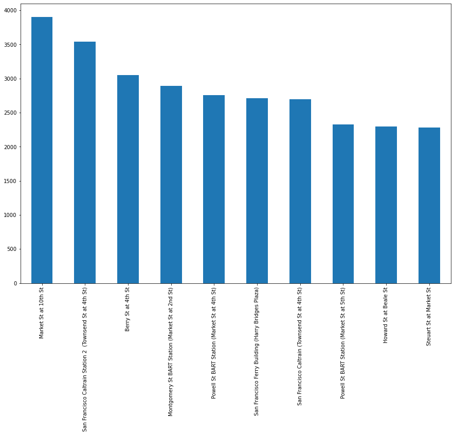

## The days with the highest number of trips by Ford GoBike System

> The highest number of trips is on Thursday, when the number of trips reached more than 35,000 trips by Ford GoBike System.

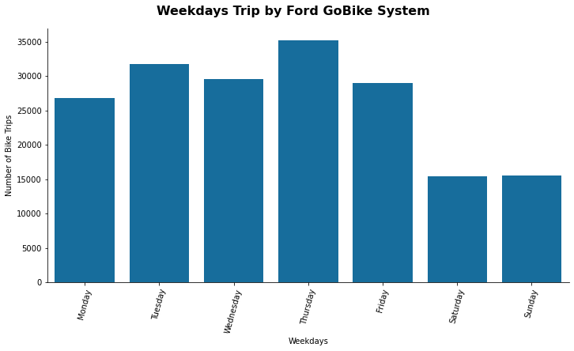

## Highest trips duration minutes for the number of trips

> The duration of the trip is between 4 to 15 minutes, so we conclude that the riders ride the bike in short distances.

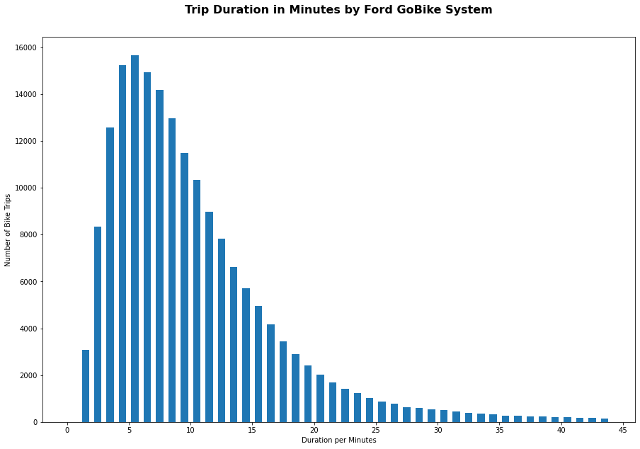

## Highest average age used Ford GoBike System

> The highest number of trips was for young people from the age of 20 to 40, And the highest at the age of 30 to 35.

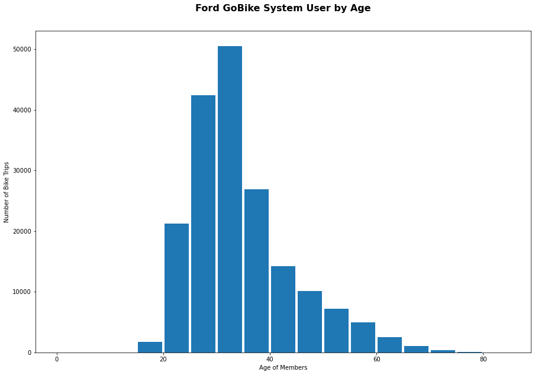

## Distribution of User Type

> The graph shows that the number of subscriber users exceeds 160000, while the number of customers is only 20000.

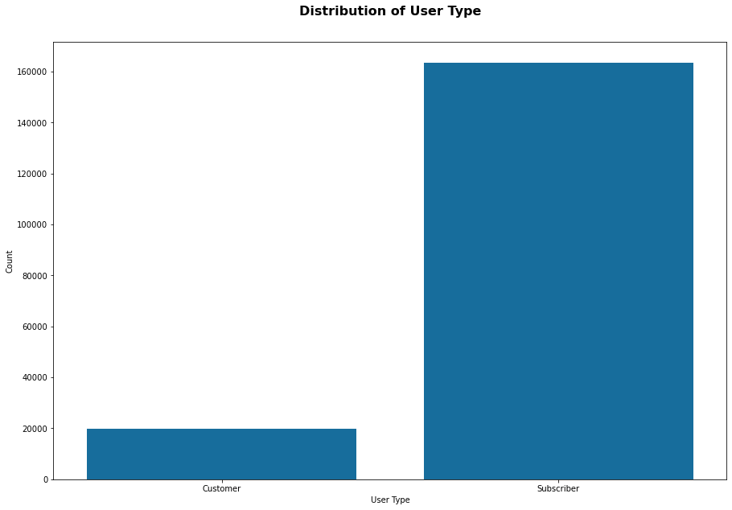

## Distribution of Gender

> The number of male users exceeds the number of female users by a very large percentage, as the number of male users has reached more than 130,000, while the number of female users is approximately 40,000.

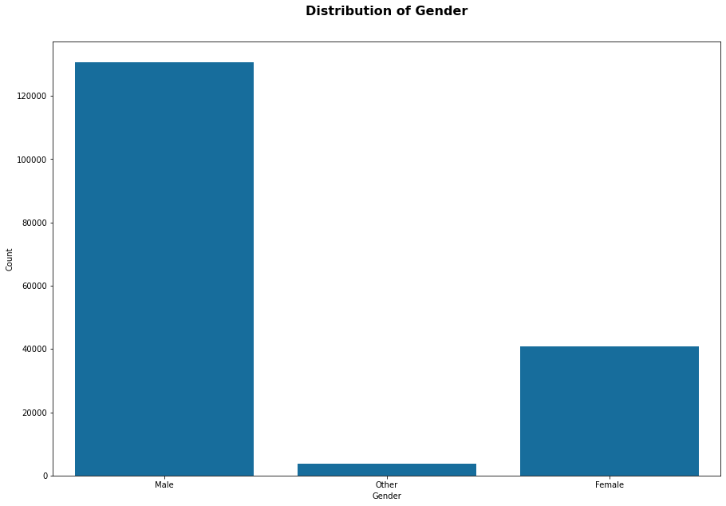

## Distribution of trip duration between subscribers and customers

> Through violinplot we find that the trip duration for subscribers is much shorter than that of customer and we conclude that subscribers have more limited use for short distances while customers rent bikes for a longer period.

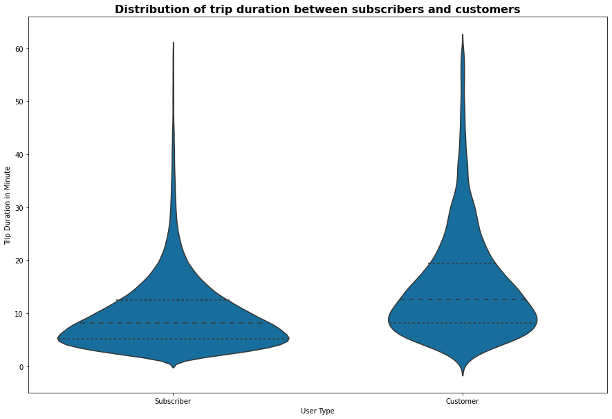

## Distribution trips on weekdays between subscribers and customers

> Through the graph, we find that the subscribers’ use of the bicycle is much more than the customers, and here we find that the subscribers’ use of the bicycle on normal days indicates that they use it to go to work as a means of transportation, while the clients use the bicycle indicates that they use it as a means of entertainment.

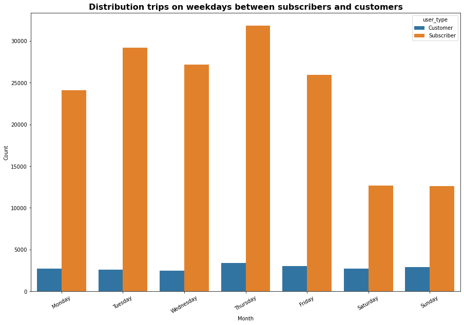

## Duration of Bike Trips Each Weekday (Start Days-End Days)

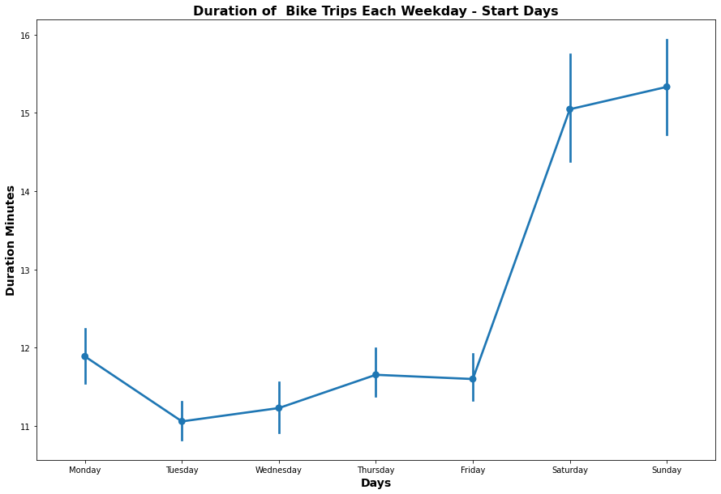

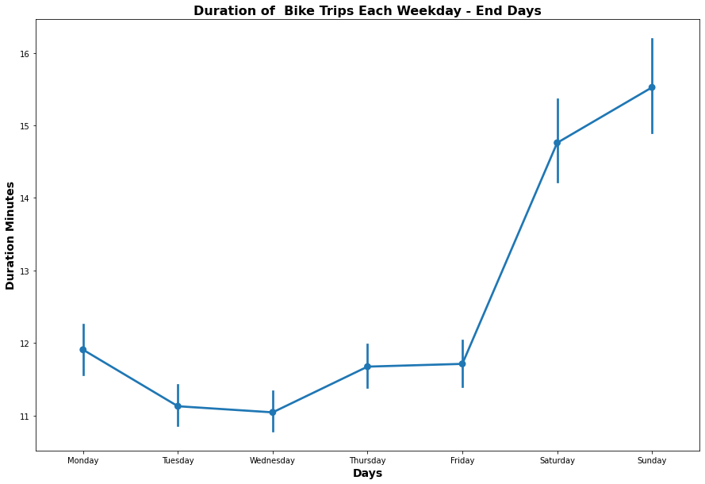

## Most Common Hours For Having Bike Trips

> Through this multiple perception, we find that, as we previously knew, men use bicycles more than women, and also the length of the hourly trip was 8 to 10 and 16 to 18 hours.

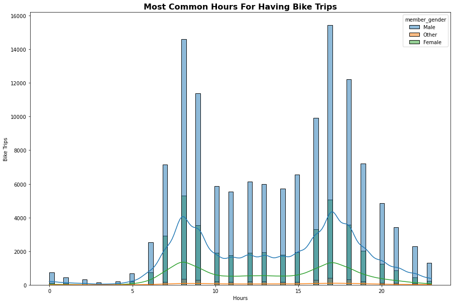

## Most Common Age For Having Bike Trips

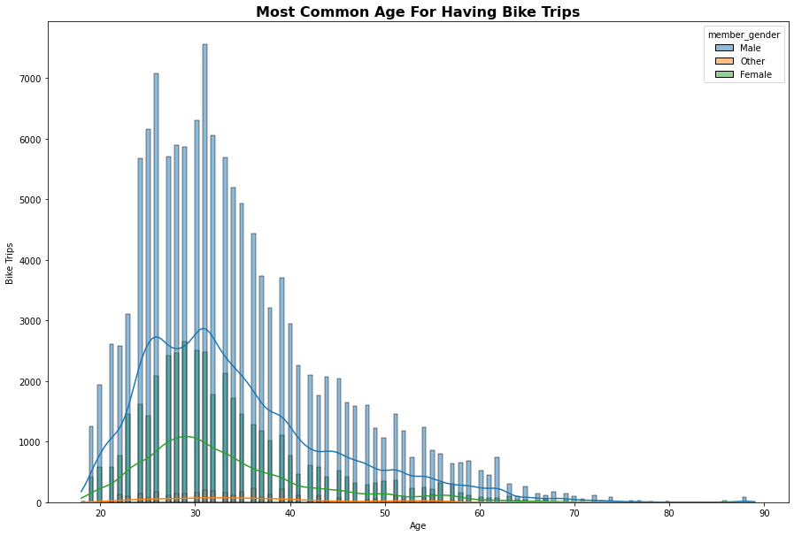

## Trip duration in each weekday according to user type

> In the short period of time there is almost no difference between subscribers and customers, while in the large period of time there is a difference between them as the customers are more than the subscribers.

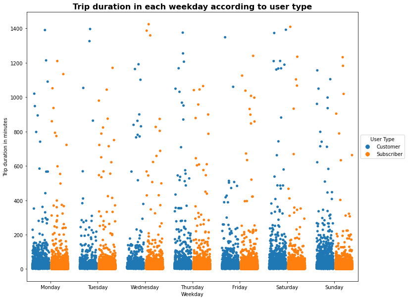

## Bike sharing system per user type and gender During the weekdays

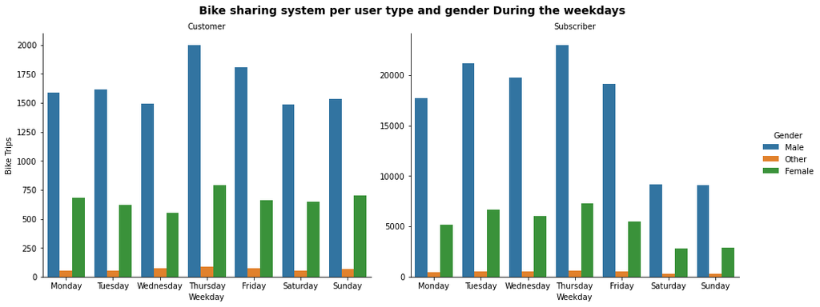

## Hourly usage during the weekday for customers and subscribers

> Subscribers: They bike regularly throughout the week and most bike rides start around 8-9 am. and 5-6 p.m. and culminate on Thursdays around 8 am and 5 pm.

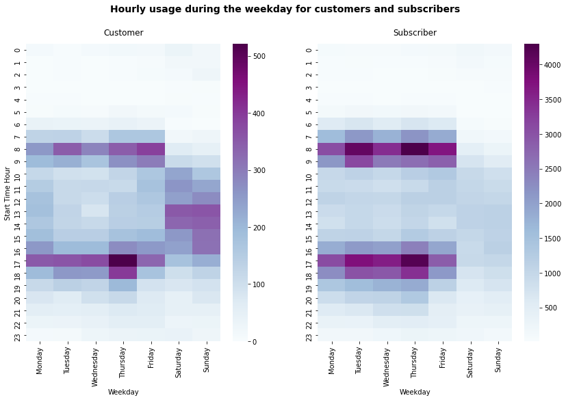